# Analysis on Life Expectancy using Bayesian Linear Regression

Author

Mary Catherine Morrow, Kayla Mota, Summer Dahlen, Shijie Geng

Published

April 26, 2024

Slides

## 1. Introduction

Bayesian Linear Regression (BLR) is a conditional data analytical method for understanding the relationship between independent and dependent variables based on Bayes Theorem while handling uncertainties with accuracy and interpretability(Walker, Gustafson, and Frimer 2007). In the prevalent perspective, the primary method for estimating parameters in a linear regression model is the frequentist approach. However, this methodology defines the probability of uncertain events as the relative frequency of their occurrence(Hájek 1996), and the resulting model parameters are derived exclusively from the observed data (Hájek 2009). Additionally, the frequentist approach may distort parameter estimates and affect the validity of statistical tests when dealing with a small datatset (Zyphur and Oswald 2015). Unlike frequentist method, BLR is a more flexible statistical model in that it captures all uncertain variables random (Klauenberg et al. 2015) and is also known to be used for experiments that have small sample sizes (Sugiarto et al. 2021) and various data types (Kruschke 2010). Moreover, BLR eliminates the need for p-values, which offers richer information on parameters, and allows for simultaneous single change point detection in a multivariate sample (Seidou, Asselin, and Ouarda 2007).

The BLR is characterized by viewing parameters as random variables, introducing the concept of prior, likelihood, and posterior distributions (Permai and Tanty 2018; Chen et al. 2024). The BLR method involves multiple steps: predicting prior values, imputting collected data, and obtaining probability in the form of a distribution. This distribution, called the posterior, is proportional to the prior distribution multiplied by the likelihood function (Baldwin and Larson 2017). In BLR, even when utilizing representative or informed priors, it is crucial to perform a sensitivity analysis to assess the impact of different prior specifications on the posterior results. This aims to ensure that the findings are not dependent on the choice of prior (Kruschke 2021). Once the experiment is conducted and the posterior distribution is obtained, the next step is to conduct a check on skewness of the distributions, as well as heteroscedasticity. Although scale mixtures of normal are often used in regression analysis to capture heteroscedasticity and outliers, skew-symmetric scale mixtures of normal (SSSM) can capture asymmetry, making it more robust to use in BLR (Rubio and Genton 2016). The posterior distribution is where the Markov Chain Monte Carlo (MCMC) method involves simulating random draws from the posterior distribution, allowing for exploration of the parameter space and estimation of the posterior distribution even in complex, high-dimensional models (Robert et al. 2018; Rojas and Yampolsky 2020). Confirming the convergence of MCMC chains is important for the reliability of the results. Evidence of convergence provides confidence in the validity of the samples(Marcotte and Allard 2018). After obtaining the posterior results, inferences can be used for the prior distribution of the current/next experiment (Rubio and Genton 2016). The steps for creating a BLR can be found in Figure. 1 (Klauenberg et al. 2015).

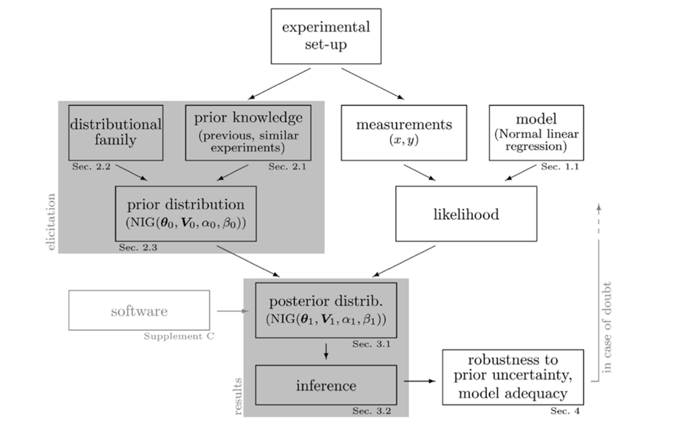

Figure. 1 Bayesian Linear Regression Workflow

To explain, posterior probabilities are assigned to the spectrum of values that parameters can assume. The more prominent the peak, the more effective it is as an estimate because a single value has a higher probability compared to other values. In such cases, the credibility interval, indicating a 95% range of probable parameter estimates, is narrower. Conversely, when the peak is less pronounced, other estimates are also plausible, resulting in a wider credibility interval for the 95% range of probable parameter estimates (Shetty, Kelly, and Bigiel 2013; Gill 2002).

BLR has been used in many disciplines due to its numerous strengths. Researchers have the option to incorporate past findings as informative priors, a practice observed in fields such as construction and biomedicine. This analytical approach produces outcomes that amalgamate previous results with the data from a present study, treating it as if all existing datasets were collectively analyzed. An example of using BLR includes determining correction coefficients to previously inaccurate concrete mixture formulas to ensure the correct use and amount of chemicals to prevent and then predict the breakdown of the concrete (Zgheib and Raphael 2019). Another example of BLR is re-determining traffic-flow rate values for vehicles to be able to ensure optimal traffic flow and minimize to a safe number of vehicles at intersections, which allows for the previous rate values from over 20 years ago to be updated (Sugiarto et al. 2021). BLR can also be used to determine the load and strain a bridge can take before it is unsafe to be used (Zhang et al. 2022), and it can be helpful to predict genetic values for genomic selection for plants and animals to prevent the risk of passing on genes that could cause illnesses (Pérez et al. 2010).

## 2. Methods

### 2.1 Linear Regression

Regression analysis is a statistical method that allows to examine the relationship between two or more variables of interest. Suppose the response variable $Y$ is a function of several predictor variables, $x_{i1}, x_{i2},..., x_{ik}$.

To fit a model:

$$Y = X \beta + \epsilon \quad(1)$$

where,

$Y = (y_1, y_2,..., y_n)$ is the n×1 vector of response; $X$ is a n×p design matrix, $p = k+1$; $\beta = (\beta_0, \beta_1,...., \beta_{k})$ is the (k+1)×1 vector of parameters and $\epsilon = (\epsilon_1, \epsilon_2,...., \epsilon_n)$ the n×1 vector of errors, $\epsilon$ ~ $N_n(0, \sigma^2I)$.

The likelihood function of $y$ given $\beta$ and $\sigma^2$ is defined as follows

$$f(Y_i = y_i|x, \beta, \sigma^2) = f_y(y|x,\beta,\sigma^2) = (2\pi\sigma^2)^{-\frac{n}{2}} exp^{-\frac{1}{2\sigma^2}(y-x\beta)^T(y-x\beta)} \quad(2)$$

To make inference, the $\beta$ parameters are determined by maximizing the likelihood function.

### 2.2 Bayesian Linear Regression

From the Bayesian perspective, linear regression is approached through probability distributions. Instead of estimating the response variable, y, as a single value, it’s viewed as being drawn from a probability distribution. In Bayesian Linear Regression, the model assumes that the response follows a normal distribution, expressed as

$$y \sim N(\beta^TX, \sigma^2I) \quad(3)$$

where,

y, which is assumed as a normal distribution centered by its mean and variance. In linear regression, the mean is calculated by the transpose of the weight matrix and the predictor matrix. The variance is determined by squaring the standard deviation $\sigma$ and then multiplying it by the identity matrix.

Additionally, the parameters in the model are generated from a probability distribution. The posterior probability of these parameters is proportional to the prior and likelihood (Minka 2000).

$$P(\beta|y, X) = \frac{P(y|\beta, X) × P(\beta|X)}{P(y|X)} \quad(4)$$

In Bayesian statistics, when the prior distribution and the posterior distribution belong to the same family of probability distributions, they are called conjugate distributions. Using the Bayes’ theorem, we have

$$f(\beta, \sigma^2|y,x) = \frac{f_y(y|x, \beta,\sigma^2)f(\beta|\sigma^2,m,V)f(\sigma^2|a,b)}{f_y(y)} \quad(5)$$

The equation can be broken down as,

- $f(\beta, \sigma^2|y,x)$: This is the joint posterior distribution of the coefficients $\beta$ and the error variance $\sigma^2$ given the data $y$ and the predictors $x$
- $f_y(y|x, \beta,\sigma^2)$: This is the likelihood function which describes the probability of observing the data $y$ given the predictors $x$ and the parameters $\beta$ and $\sigma^2$.
- $f(\beta|\sigma^2,m,V)$: It represents the prior distribution for coefficients $\beta$ given the error variance $\sigma^2$, with mean vector $m$ and covariance matrix $V$.
- $f(\sigma^2|a,b)$: It represents the prior distribution for the error variance $\sigma^2$, which is assumed to be an inverse gamma distribution with parameter $a$ and $b$.
- $f_y(y)$: It is the marginal likelihood and often treated as a constant.

A non-conjugate prior refers to a prior distribution that does not belong to the same family of distributions as the posterior distribution after observing data. In such cases, the posterior distribution can be expressed as

$$f(\beta|y, X, \sigma^2) ∝ f_y(y|X, \beta)\prod_{i=1}^{n}f(\beta_i|m_i,v_i) \quad(6)$$

- $f(\beta|y, X, \sigma^2)$: This is the posterior distribution of coefficients $\beta$ given the dependent variable $y$, independent variable $X$ and error variance $\sigma^2$.
- $f_y(y|X, \beta)$: This is likelihood function, denoting the probability of the observing data $y$ given independent variable $X$ and the coefficient parameters $\beta$.
- $f(\beta_i|m_i,v_i)$: This is prior distribution of each coefficient $\beta_i$ with mean $m_i$ and variance $v_i$.

## 3. Analysis and Results

### 3.1 Data Introduction

The selected life expectancy dataset from the World Health Organization (WHO) comprises of 21 health, economic, and social factors taken from 179 countries between years 2000 and 2015. Below is a description of the variables:

- **Country:** Categorical, one of 179 countries included in the dataset specific to data collection location.
- **Region:** Categorical, one of 9 regions specific to data collection location.
- **Year:** Continuous, range from 2000 to 2015.
- **Infant Deaths (InfDth):** Continuous, per 1000 population.
- **Under_five_deaths (UnFiveDths):** Continuous, number of deaths of children under 5 years of age per 1000 population.
- **Adult Mortality (AdultMort):** Continuous, rate of deaths of adults between 15 and 60 years old, per 1000 population.
- **Alcohol_consumption:** Continuous, recorded per capita (15+ year olds) consumption in litres of pure alcohol.
- **Hepatitis B (HepB):** Continuous, percentage of Hepatitis B (HepB) immunization coverage among 1-year-old.
- **Measles:** Continuous, percentage of coverage of Measles containing vaccine first dose (MCV1) immunization among 1-year-old.
- **BMI:** Continuous, average body mass index (BMI) of entire population; measure of nutritional status in adults.
- **Polio :** Continuous, percentage of Polio (Pol3) immunization coverage among 1-year-old.
- **Diphtheria :** Continuous, percentage of diphtheria tetanus toxoid and pertussis (DTP3) immunization coverage among 1-year-old.
- **Incidents_HIV (HIV):** continuous, incidents of HIV per 1000 population, ages 15-49.
- **GDP_per_capita (GDP):** Continuous, GDP per capita in USD.
- **Population_mln (Population):** Total population in millions.
- **Thinness_ten_nineteen_years (ThinAd):** Continuous, prevalence of thinness among children and adolescents for ages 10 to 19, %.
- **Thinness_five_nine_years (ThinChild):** Continuous, prevalence of thinness among children for ages 5 to 9, %.
- **Economy_status_Developed:** Categorical, Binomial; Developed Country.
- **Economy_status_Developing:** Categorical, Binomial; Developing Country.
- **Schooling:** Continuous, average years that people aged 25+ spent in formal education.
- **Life_expectancy (LifeExp):** Continuous, average of the population of both genders in years.

#### 3.1.1 Load the dataset and inspect the first five records.

```r
# loading the packages required for data cleaning and BLR analysis.
library(tidyverse)
library(gtsummary)
library(skimr)
library(randomForest)
library(GGally)
library(corrplot)
library(car)
library(ggrepel)
library(rstan)
library(rstanarm)
library(bayesplot)

# Read CSV file directly from a website URL

url = "C:/Users/shiji/OneDrive/桌面/STA6257_capstone/Life-Expectancy-Data-Updated.csv"
ledata = read.csv(url, header = TRUE)



names(ledata) <- c("Country", 'Region',"Year", "InfDth","UnFiveDths","AdultMort", "Alcohol","HepB","Measles","BMI","Polio", "Diphtheria", "HIV", "GDP", "population","ThinAd","ThinChild","Schooling",'Developing','Developed', "LifeExp")
str(ledata)
```

```
'data.frame':   2864 obs. of  21 variables:
 $ Country   : chr  "Turkiye" "Spain" "India" "Guyana" ...
 $ Region    : chr  "Middle East" "European Union" "Asia" "South America" ...
 $ Year      : int  2015 2015 2007 2006 2012 2006 2015 2000 2001 2008 ...
 $ InfDth    : num  11.1 2.7 51.5 32.8 3.4 9.8 6.6 8.7 22 15.3 ...
 $ UnFiveDths: num  13 3.3 67.9 40.5 4.3 11.2 8.2 10.1 26.1 17.8 ...
 $ AdultMort : num  105.8 57.9 201.1 222.2 58 ...
 $ Alcohol   : num  1.32 10.35 1.57 5.68 2.89 ...
 $ HepB      : int  97 97 60 93 97 88 97 88 97 97 ...
 $ Measles   : int  65 94 35 74 89 86 97 99 87 92 ...
 $ BMI       : num  27.8 26 21.2 25.3 27 26.4 26.2 25.9 27.9 26.5 ...
 $ Polio     : int  97 97 67 92 94 89 97 99 97 96 ...
 $ Diphtheria: int  97 97 64 93 94 89 97 99 99 90 ...
 $ HIV       : num  0.08 0.09 0.13 0.79 0.08 0.16 0.08 0.08 0.13 0.43 ...
 $ GDP       : int  11006 25742 1076 4146 33995 9110 9313 8971 3708 2235 ...
 $ population: num  78.53 46.44 1183.21 0.75 7.91 ...
 $ ThinAd    : num  4.9 0.6 27.1 5.7 1.2 2 2.3 2.3 4 2.9 ...
 $ ThinChild : num  4.8 0.5 28 5.5 1.1 1.9 2.3 2.3 3.9 3.1 ...
 $ Schooling : num  7.8 9.7 5 7.9 12.8 7.9 12 10.2 9.6 10.9 ...
 $ Developing: int  0 1 0 0 1 0 0 1 0 0 ...
 $ Developed : int  1 0 1 1 0 1 1 0 1 1 ...
 $ LifeExp   : num  76.5 82.8 65.4 67 81.7 78.2 71.2 71.2 71.9 68.7 ...
```

### 3.2 Exploration Data Analysis

#### 3.2.1 Summarize the Dataset

Table 1 below describes each continuous variable from the life expectancy dataset by region.

```r
ledata %>% select(-c('Country', 'Year')) %>%
  tbl_summary(
    by = Region,
    label = list(InfDth ~ "Infant Deaths, per 1000",
                 UnFiveDths ~ "Deaths under 5 years of age",
                 AdultMort ~ "Adult Mortality Probability",
                 Alcohol ~ "Alcohol Consumption (L)",
                 HepB ~ "Hepatitis B Immunization (%)",
                 Measles ~ "Measles Immunization (%)",
                 BMI ~ "Average Body Mass Index",
                 Polio ~ "Polio immunization (%)",
                 Diphtheria ~ "Diphtheria Tetanus Toxoid and Pertussis immunization (%)",
                 HIV ~ "Incidents of HIV per 1000",
                 GDP ~ "Gross Domestic Product (USD)",
                 population ~ "Population, in millions",
                 ThinAd ~ "Thinness among 10-19 years (%)",
                 ThinChild ~ "Thinness among 5-9 years (%)",
                 Schooling ~ "Average Years of Schooling",
                 Developed ~ "Developed Country",
                   Developing ~ "Developing Country",
                 LifeExp ~ "Life Expectancy (yrs)"),
    missing_text = "(Missing)",
    statistic = list(
      all_continuous()~ "{mean} ({sd})",
      all_categorical()~ "{n}/{N} ({p}%)"
    )
  ) %>%
  add_n()%>%
  add_overall()%>%
  modify_header(label="**Variable**") %>%
  modify_caption("**Table 1. Dataset Summary**") %>%
  modify_footnote(all_stat_cols()~ "Mean (SD)") %>%
  bold_labels()
```

**Table 1. Dataset Summary**

| **Variable** | **N** | **Overall**, N = 2,864<sup>1</sup> | **Africa**, N = 816<sup>1</sup> | **Asia**, N = 432<sup>1</sup> | **Central America and Caribbean**, N = 304<sup>1</sup> | **European Union**, N = 432<sup>1</sup> | **Middle East**, N = 224<sup>1</sup> | **North America**, N = 48<sup>1</sup> | **Oceania**, N = 176<sup>1</sup> | **Rest of Europe**, N = 240<sup>1</sup> | **South America**, N = 192<sup>1</sup> |
| --- | --- | --- | --- | --- | --- | --- | --- | --- | --- | --- | --- |
| Infant Deaths, per 1000 | 2,864 | 30 (28) | 61 (26) | 33 (21) | 21 (14) | 5 (3) | 17 (13) | 10 (6) | 26 (18) | 10 (6) | 20 (9) |
| Deaths under 5 years of age | 2,864 | 43 (45) | 94 (46) | 41 (28) | 26 (21) | 6 (3) | 20 (17) | 12 (7) | 32 (23) | 11 (7) | 24 (12) |
| Adult Mortality Probability | 2,864 | 192 (115) | 319 (124) | 171 (59) | 164 (42) | 104 (44) | 111 (49) | 101 (21) | 163 (55) | 139 (70) | 155 (36) |
| Alcohol Consumption (L) | 2,864 | 4.8 (4.0) | 3.0 (2.9) | 2.4 (2.5) | 5.6 (2.7) | 10.8 (2.1) | 0.9 (0.9) | 7.1 (1.9) | 2.9 (3.3) | 7.6 (2.9) | 5.7 (1.6) |
| Hepatitis B Immunization (%) | 2,864 | 84 (16) | 78 (17) | 84 (16) | 90 (10) | 89 (12) | 88 (15) | 73 (31) | 81 (15) | 87 (13) | 88 (9) |
| Measles Immunization (%) | 2,864 | 77 (19) | 68 (16) | 73 (24) | 83 (9) | 89 (11) | 84 (17) | 88 (5) | 71 (18) | 90 (10) | 74 (22) |
| Average Body Mass Index | 2,864 | 25.03 (2.19) | 23.25 (1.76) | 23.41 (1.78) | 26.27 (1.17) | 26.02 (0.59) | 26.93 (1.56) | 27.43 (0.73) | 27.20 (3.06) | 25.99 (0.55) | 26.07 (0.72) |
| Polio immunization (%) | 2,864 | 86 (15) | 76 (19) | 88 (14) | 91 (10) | 96 (4) | 90 (11) | 93 (4) | 82 (14) | 93 (8) | 89 (7) |
| Diphtheria Tetanus Toxoid and Pertussis immunization (%) | 2,864 | 86 (16) | 76 (20) | 88 (13) | 91 (10) | 96 (4) | 90 (12) | 94 (4) | 81 (14) | 92 (9) | 90 (8) |
| Incidents of HIV per 1000 | 2,864 | 0.89 (2.38) | 2.70 (3.91) | 0.14 (0.11) | 0.42 (0.30) | 0.07 (0.04) | 0.09 (0.04) | 0.13 (0.02) | 0.16 (0.12) | 0.11 (0.12) | 0.30 (0.23) |
| Gross Domestic Product (USD) | 2,864 | 11,541 (16,935) | 2,314 (3,010) | 6,561 (11,318) | 8,388 (7,744) | 28,140 (20,444) | 18,957 (17,872) | 33,784 (18,650) | 10,147 (16,224) | 19,090 (26,521) | 7,232 (3,642) |
| Population, in millions | 2,864 | 37 (136) | 18 (27) | 136 (323) | 4 (4) | 16 (21) | 19 (23) | 148 (115) | 3 (6) | 20 (37) | 32 (50) |
| Thinness among 10-19 years (%) | 2,864 | 4.9 (4.4) | 7.3 (2.7) | 8.8 (7.2) | 3.3 (1.4) | 1.4 (0.8) | 5.9 (2.8) | 1.0 (0.5) | 1.9 (3.1) | 2.0 (0.8) | 2.2 (1.3) |
| Thinness among 5-9 years (%) | 2,864 | 4.9 (4.5) | 7.2 (2.8) | 9.3 (7.2) | 3.3 (1.5) | 1.4 (0.8) | 5.8 (2.8) | 0.9 (0.6) | 1.9 (3.3) | 2.0 (0.9) | 2.1 (1.3) |
| Average Years of Schooling | 2,864 | 7.6 (3.2) | 4.6 (2.0) | 7.4 (3.0) | 7.8 (2.2) | 11.1 (1.3) | 7.7 (2.4) | 11.0 (2.4) | 7.9 (2.9) | 10.8 (1.6) | 8.0 (1.0) |
| Developing Country | 2,864 | 592/2,864 (21%) | 0/816 (0%) | 16/432 (3.7%) | 0/304 (0%) | 432/432 (100%) | 16/224 (7.1%) | 32/48 (67%) | 32/176 (18%) | 64/240 (27%) | 0/192 (0%) |
| Developed Country | 2,864 | 2,272/2,864 (79%) | 816/816 (100%) | 416/432 (96%) | 304/304 (100%) | 0/432 (0%) | 208/224 (93%) | 16/48 (33%) | 144/176 (82%) | 176/240 (73%) | 192/192 (100%) |
| Life Expectancy (yrs) | 2,864 | 69 (9) | 58 (8) | 69 (6) | 72 (4) | 78 (3) | 74 (4) | 78 (2) | 70 (6) | 75 (5) | 73 (4) |

<sup>1</sup> Mean (SD)

#### 3.2.2 Verify the correlation among variables.

```r
# Checking the correlation between those continuous variables and life expectancy.
# Remove these categorical variables from dataset.
ledata_continuous <- ledata %>% select(-c('Country', 'Region', 'Year', 'Developing', 'Developed'))

# Remove NA values from ledata_continuous
ledata_noNA <- na.omit(ledata_continuous)
#co_ledata <- ledata_noNA %>% select(-c('Country', 'Region', 'Year'))

# Compute correlation of continuous variables and life expectancy
cor(ledata_noNA)
```

```
                InfDth   UnFiveDths   AdultMort     Alcohol        HepB
InfDth      1.00000000  0.985651346  0.79466086 -0.45452615 -0.51256224
UnFiveDths  0.98565135  1.000000000  0.80236112 -0.40936740 -0.50742741
AdultMort   0.79466086  0.802361123  1.00000000 -0.24479376 -0.34488221
Alcohol    -0.45452615 -0.409367397 -0.24479376  1.00000000  0.16843582
HepB       -0.51256224 -0.507427407 -0.34488221  0.16843582  1.00000000
Measles    -0.52628201 -0.512971742 -0.41615254  0.31860293  0.42916779
BMI        -0.66198827 -0.665255042 -0.52286551  0.28403195  0.34542091
Polio      -0.74079046 -0.742983474 -0.52422554  0.30192623  0.72434526
Diphtheria -0.72187465 -0.725355032 -0.51380270  0.29901592  0.76178009
HIV         0.34945826  0.369617726  0.69911938 -0.03411801 -0.07578195
GDP        -0.51228611 -0.469681668 -0.51012141  0.44396595  0.15937504
population  0.00762199 -0.005234231 -0.05384768 -0.03911866 -0.08239640
ThinAd      0.49119174  0.466978458  0.38214030 -0.44636618 -0.20845350
ThinChild   0.47763934  0.450755699  0.37979229 -0.43302972 -0.21379442
Schooling  -0.78851253 -0.773195983 -0.58103548  0.61572804  0.34764345
LifeExp    -0.92003192 -0.920419134 -0.94536036  0.39915911  0.41780443
               Measles        BMI       Polio  Diphtheria         HIV
InfDth     -0.52628201 -0.6619883 -0.74079046 -0.72187465  0.34945826
UnFiveDths -0.51297174 -0.6652550 -0.74298347 -0.72535503  0.36961773
AdultMort  -0.41615254 -0.5228655 -0.52422554 -0.51380270  0.69911938
Alcohol     0.31860293  0.2840319  0.30192623  0.29901592 -0.03411801
HepB        0.42916779  0.3454209  0.72434526  0.76178009 -0.07578195
Measles     1.00000000  0.4163214  0.51409629  0.49405877 -0.15058000
BMI         0.41632141  1.0000000  0.45720604  0.42650090 -0.16114208
Polio       0.51409629  0.4572060  1.00000000  0.95317790 -0.14795220
Diphtheria  0.49405877  0.4265009  0.95317790  1.00000000 -0.14693191
HIV        -0.15058000 -0.1611421 -0.14795220 -0.14693191  1.00000000
GDP         0.31372372  0.3361796  0.31378567  0.31332094 -0.16958972
population -0.09822189 -0.1664820 -0.03348589 -0.02733598 -0.05803971
ThinAd     -0.34070533 -0.5964833 -0.31268545 -0.30446625  0.18876454
ThinChild  -0.36696995 -0.5991122 -0.30699811 -0.29559745  0.19384734
Schooling   0.49839128  0.6354752  0.55276511  0.53562097 -0.20124620
LifeExp     0.49001859  0.5984233  0.64121746  0.62754139 -0.55302746
                   GDP   population     ThinAd  ThinChild   Schooling
InfDth     -0.51228611  0.007621990  0.4911917  0.4776393 -0.78851253
UnFiveDths -0.46968167 -0.005234231  0.4669785  0.4507557 -0.77319598
AdultMort  -0.51012141 -0.053847680  0.3821403  0.3797923 -0.58103548
Alcohol     0.44396595 -0.039118659 -0.4463662 -0.4330297  0.61572804
HepB        0.15937504 -0.082396398 -0.2084535 -0.2137944  0.34764345
```

[output cut: 13 more lines]

```
UnFiveDths -0.92041913
AdultMort  -0.94536036
Alcohol     0.39915911
HepB        0.41780443
Measles     0.49001859
BMI         0.59842332
Polio       0.64121746
Diphtheria  0.62754139
HIV        -0.55302746
GDP         0.58308972
population  0.02629788
ThinAd     -0.46782450
ThinChild  -0.45816623
Schooling   0.73248447
LifeExp     1.00000000
```

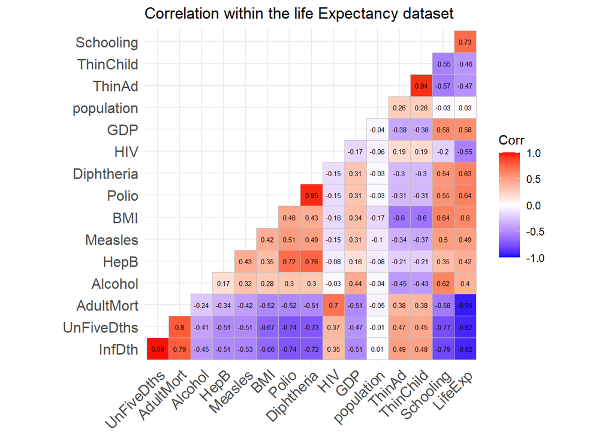

```r
# Visualize correlation matrix

ggcorrplot::ggcorrplot(round(cor(ledata_noNA),2), type = 'lower', title = 'Correlation within the life Expectancy dataset', show.legend = TRUE, lab = TRUE, lab_size = 2)
```

After conducting a correlation analysis, we identified that the variables adult mortality, deaths under five years old and infant deaths each have a strong negative correlation with life expectancy. The variable population is not related to life expectancy at all. We consider setting threshold of correlation between [-1.00 < -0.55] and [0.55 < 1.00]. Any variables’ correlation with response between [-1.00 < -0.55] and [0.55 < 1.00] can be included for Bayesian Linear Regression. Thus, GDP, BMI, Dephtheria, Polio, schooling, and HIV also can be used to predict life expectancy.

#### 3.2.3 Multicollinearity Examination

```r
# Build a ordinary linear model for subsequent vif check
olr <- lm(LifeExp ~., data = ledata_noNA)

# Check Multicollinearity using vif()
vif(olr)
```

```
    InfDth UnFiveDths  AdultMort    Alcohol       HepB    Measles        BMI
 44.329144  44.469991   7.618888   1.939630   2.560952   1.587422   2.627136
     Polio Diphtheria        HIV        GDP population     ThinAd  ThinChild
 11.990081  12.940367   2.890280   2.016715   1.150097   8.949993   8.936053
 Schooling
  4.273524
```

```r
# Extract selected variables for subsequent BLR analysis
BLR_data <- ledata_noNA %>% select(c(GDP, BMI, Alcohol, Schooling, HIV,LifeExp))
```

Through checking the multicollinearity among these variables, the vif values of infant deaths, deaths under five years old, adult mortality, Polio, Diphtheria, thinness among those between 10 and 19, and thinness among children for ages 5 to 9 are greater than 5, indicating significant multicollinearity between them. Thus, given the results of correlation and multicollinearity checking, we select the independent variables of GDP, BMI, alcohol, schooling and HIV and dependent variable of life expentency to contribute to our final dataset used for BLR analysis.

#### 3.2.4 Data Visualization

Life expectancy follows a distribution skewed to the left, with the peak occurring at 70-75 years for the highest life expectancy.

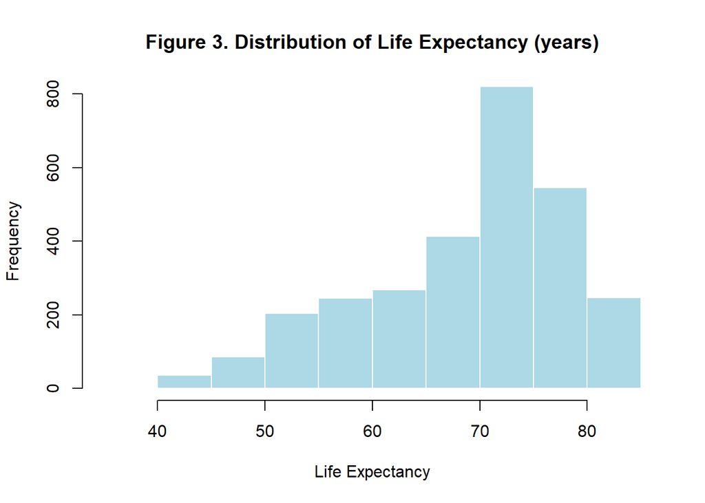

```r
hist(ledata_noNA$LifeExp,
     main = "Figure 3. Distribution of Life Expectancy (years)",
     xlab = "Life Expectancy",
     border = "white",
     col = "lightblue",
     ylim = c(0, 800))
```

The line graph illustrates the life expectancy trends across various regions over the years. There has been a consistent rise in life expectancy across all regions since 2000. North America and European Union exhibit the highest life expectancy, while Africa shows the lowest among these regions.

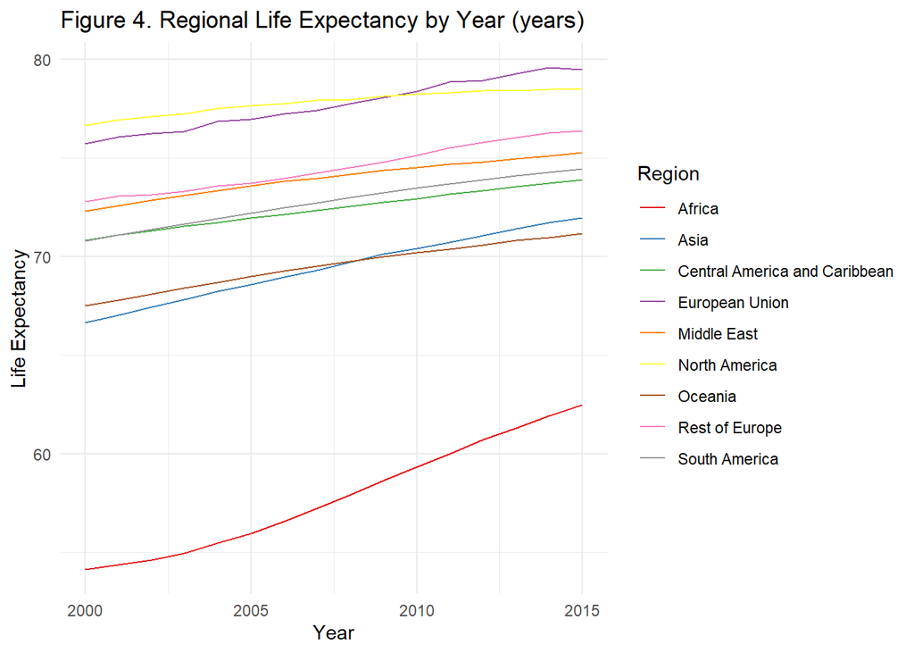

```r
# Calculate max, mean, and min life expectancy by year and region
life_expectancy_summary <- ledata %>%
  group_by(Year, Region) %>%
  summarise(
    mean_life_expectancy = mean(LifeExp) )

# Create a line plot for max, mean, and min life expectancy in all regions over the years
ggplot(life_expectancy_summary, aes(x = Year)) +
  geom_line(aes(y = mean_life_expectancy, color = Region), linetype = "solid") +
  labs(title = "Figure 4. Regional Life Expectancy by Year (years)", x = "Year", y = "Life Expectancy", color = "Region") +
  theme_minimal() +
  scale_color_brewer(palette = "Set1")
```

The graphs depict the correlation between schooling and life expectancy across different regions. Generally, life expectancy tends to increase with higher levels of schooling. Comparatively, more developed regions such as North America, the European Union, and the Rest of Europe exhibit both higher average schooling years and life expectancy.

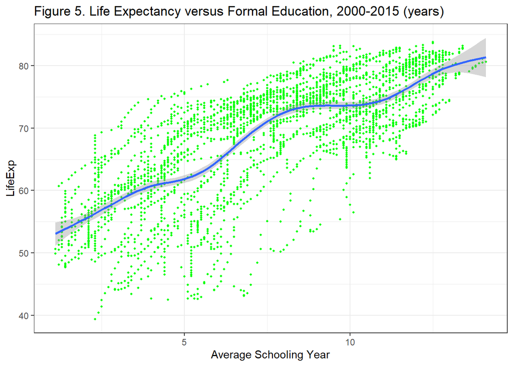

```r
ledata_noNA %>% ggplot(aes(x = Schooling, y = LifeExp)) +
  geom_point(size = 0.8, color = 'green') +
  geom_smooth()+
  theme_bw()+
  xlab('Average Schooling Year') +
  labs(title = 'Figure 5. Life Expectancy versus Formal Education, 2000-2015 (years)')
```

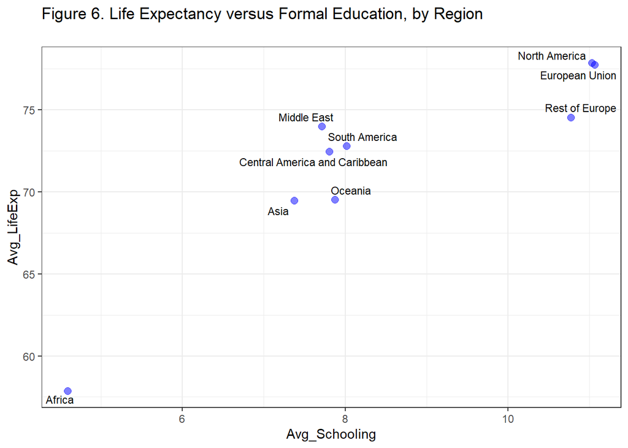

```r
ledata %>% select(Region, Schooling, LifeExp) %>%
 group_by(Region) %>%
  summarise(Avg_Schooling = mean(Schooling),
            Avg_LifeExp = mean(LifeExp)) %>%
  ggplot(aes(x = Avg_Schooling, y = Avg_LifeExp)) +
  geom_point(size = 2.5, color = 'blue', alpha = 0.5) +
  theme_bw() +
  geom_text_repel(aes(label = Region), size = 3) +
  labs(title = 'Figure 6. Life Expectancy versus Formal Education, by Region
')
```

The graphs depict the correlation between life expectancy and the variables adult mortality, deaths under five years old and infant deaths. All three variables exhibit a negative relationship with life expectancy. As the instances of adult mortality, deaths under five years old and infant deaths per 1000 rise, life expectancy decreases accordingly.

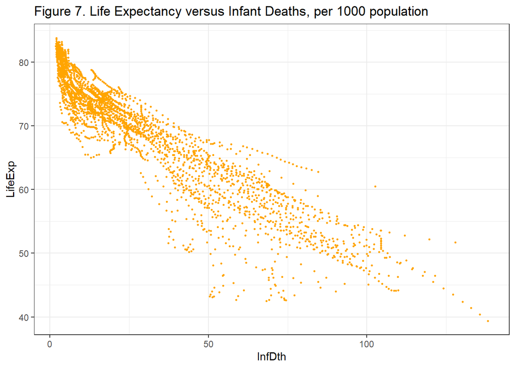

```r
ledata %>% select(Region,InfDth, AdultMort, LifeExp) %>%
  ggplot(aes(x = InfDth, y = LifeExp)) +
  geom_point(size = 0.5, color = 'orange') +
  theme_bw() +
  labs(title = 'Figure 7. Life Expectancy versus Infant Deaths, per 1000 population')
```

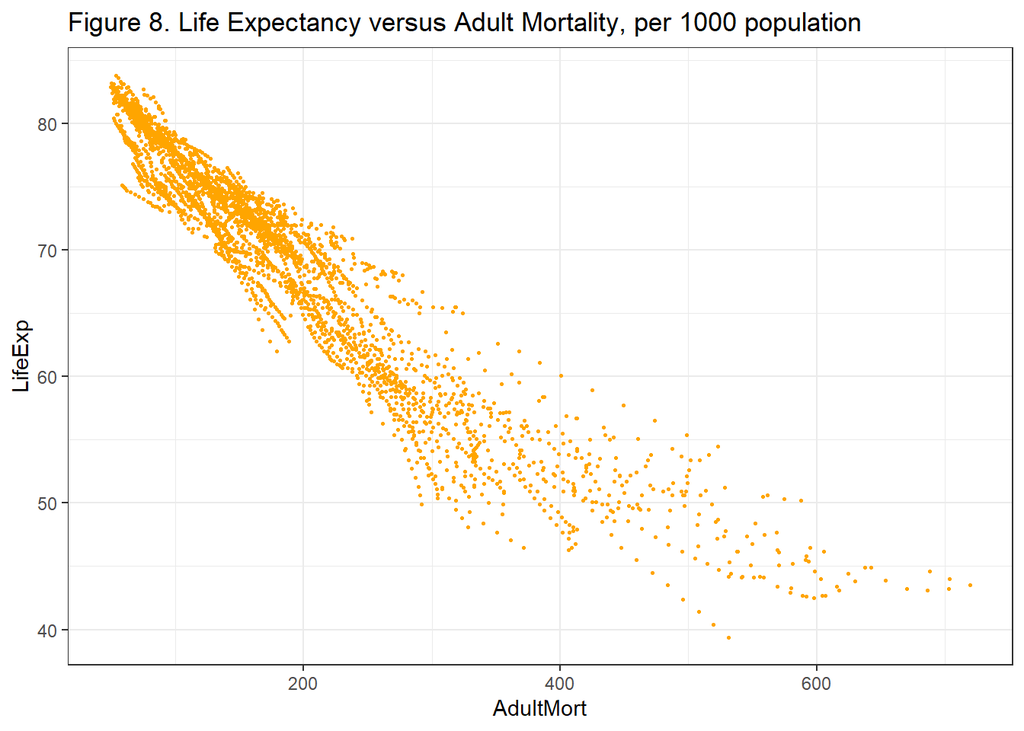

```r
ledata %>% select(InfDth, AdultMort, LifeExp) %>%
  ggplot(aes(x = AdultMort, y = LifeExp)) +
  geom_point(size = 0.5, color = 'orange') +
  theme_bw() +
  labs(title = 'Figure 8. Life Expectancy versus Adult Mortality, per 1000 population')
```

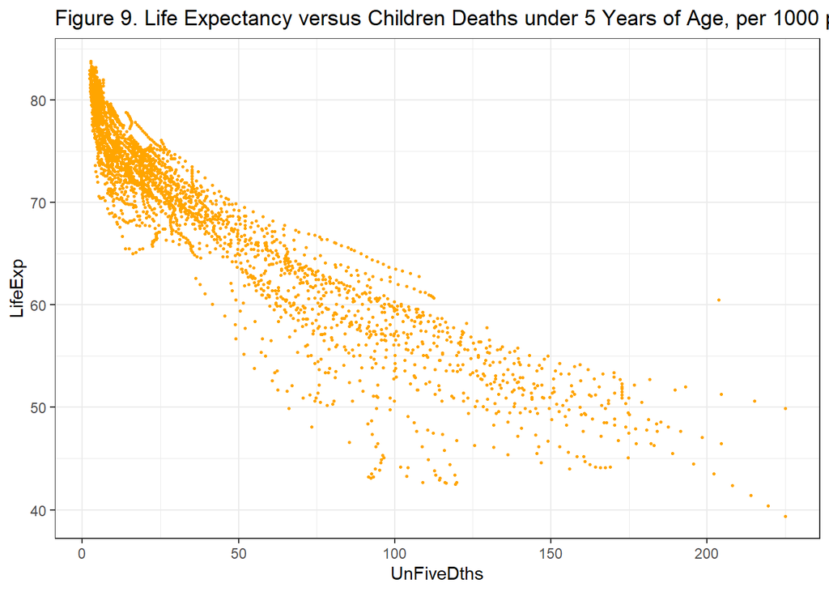

```r
ledata %>%
  ggplot(aes(x = UnFiveDths, y = LifeExp)) +
  geom_point(size = 0.5, color = 'orange') +
  theme_bw() +
  labs(title = 'Figure 9. Life Expectancy versus Children Deaths under 5 Years of Age, per 1000 population')
```

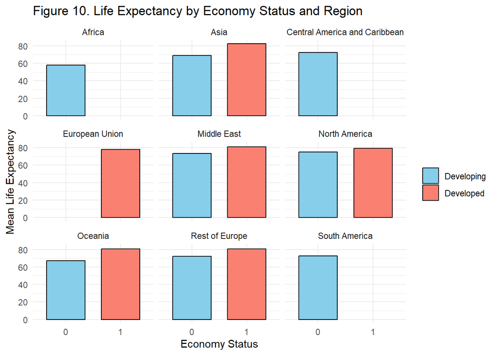

```r
ggplot(ledata, aes(x = factor(Developing), y = LifeExp, fill = factor(Developing))) +
  geom_bar(stat = "summary", fun = "mean", position = "dodge", color = "black", width = 0.7) +
  labs(title = "Figure 10. Life Expectancy by Economy Status and Region", x = "Economy Status", y = "Mean Life Expectancy") +
  scale_fill_manual(values = c("skyblue", "salmon"), labels = c("Developing", "Developed")) +
  theme_minimal() +
  theme(legend.title = element_blank()) +
  facet_wrap(~ Region)
```

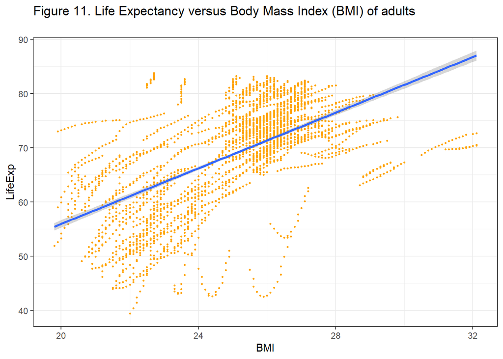

```r
ledata %>%
  ggplot(aes(x = BMI, y = LifeExp)) +
  geom_point(size = 0.5, color = 'orange') +
  theme_bw() +
  geom_smooth(method = lm) +
  labs(title = 'Figure 11. Life Expectancy versus Body Mass Index (BMI) of adults
')
```

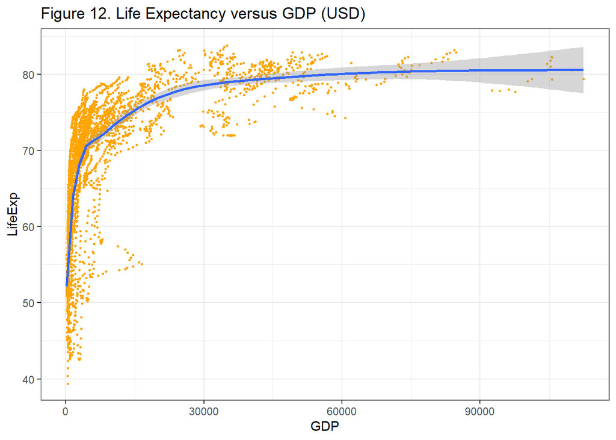

```r
ledata %>%
  ggplot(aes(x = GDP, y = LifeExp)) +
  geom_point(size = 0.5, color = 'orange') +
  theme_bw() +
  geom_smooth() +
  labs(title = 'Figure 12. Life Expectancy versus GDP (USD)')
```

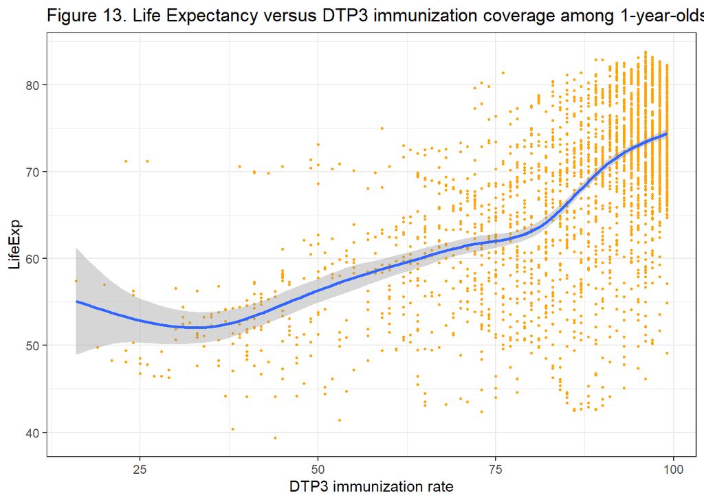

```r
ledata_noNA %>%
  ggplot(aes(x = Diphtheria, y = LifeExp)) +
  geom_point(size = 0.5, color = 'orange') +
  theme_bw() +
  geom_smooth() +
  labs(title = 'Figure 13. Life Expectancy versus DTP3 immunization coverage among 1-year-olds (%)') + xlab('DTP3 immunization rate')
```

### 3.3 Bayesian Linear Regression Analysis

#### 3.3.1 Create a BLR model

```r
# BLR model
glm_post1 <- stan_glm(LifeExp~., data=BLR_data, family=gaussian, seed = 1234)
glm_post1
```

```
stan_glm
 family:       gaussian [identity]
 formula:      LifeExp ~ .
 observations: 2864
 predictors:   6
------
            Median MAD_SD
(Intercept) 37.5    1.1
GDP          0.0    0.0
BMI          0.9    0.1
Alcohol      0.0    0.0
Schooling    1.2    0.0
HIV         -1.6    0.0

Auxiliary parameter(s):
      Median MAD_SD
sigma 4.6    0.1

------
* For help interpreting the printed output see ?print.stanreg
* For info on the priors used see ?prior_summary.stanreg
```

Upon reviewing the summary, we discern parameter estimates for the model. Notably, the model’s equation can be represented as follows:

$$LifeExp = 37.5 + 0.9×BMI + 1.2×Schooling + -1.6×HIV$$

#### 3.3.2 Evaluate the performance of BLR model

```r
# Checking R hat.
summary(glm_post1)
```

```
Model Info:
 function:     stan_glm
 family:       gaussian [identity]
 formula:      LifeExp ~ .
 algorithm:    sampling
 sample:       4000 (posterior sample size)
 priors:       see help('prior_summary')
 observations: 2864
 predictors:   6

Estimates:
              mean   sd   10%   50%   90%
(Intercept) 37.5    1.1 36.1  37.5  39.0
GDP          0.0    0.0  0.0   0.0   0.0
BMI          0.9    0.1  0.8   0.9   1.0
Alcohol      0.0    0.0 -0.1   0.0   0.0
Schooling    1.2    0.0  1.1   1.2   1.3
HIV         -1.6    0.0 -1.6  -1.6  -1.5
sigma        4.6    0.1  4.5   4.6   4.7

Fit Diagnostics:
           mean   sd   10%   50%   90%
mean_PPD 68.9    0.1 68.7  68.9  69.0

The mean_ppd is the sample average posterior predictive distribution of the outcome variable (for details see help('summary.stanreg')).

MCMC diagnostics
              mcse Rhat n_eff
(Intercept)   0.0  1.0  3758
GDP           0.0  1.0  3832
BMI           0.0  1.0  3561
Alcohol       0.0  1.0  3902
Schooling     0.0  1.0  3069
HIV           0.0  1.0  4809
sigma         0.0  1.0  3563
mean_PPD      0.0  1.0  3787
log-posterior 0.0  1.0  1849

For each parameter, mcse is Monte Carlo standard error, n_eff is a crude measure of effective sample size, and Rhat is the potential scale reduction factor on split chains (at convergence Rhat=1).
```

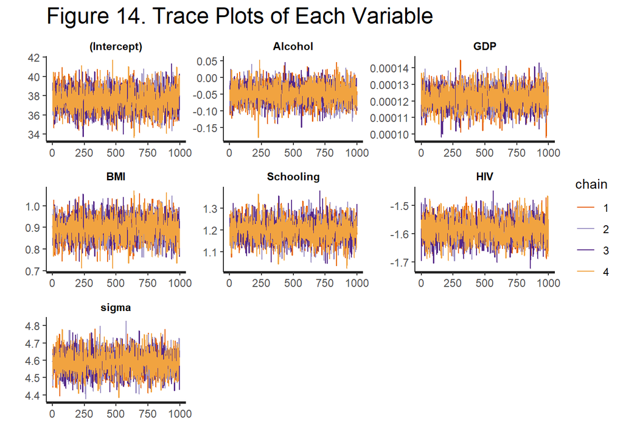

```r
# Assess the convergence of the MCMC chains and the behavior of the parameters during sampling
stan_trace(glm_post1, pars=c("(Intercept)", "Alcohol","GDP", "BMI",  "Schooling", "HIV","sigma")) + labs(title = 'Figure 14. Trace Plots of Each Variable')
```

$\hat{R}$ compares the variability in sampled parameter estimates across all chains combined with the variability within each individual change. $\hat{R} = 1$ shows stability across chains.

The **stan_trace()** function was used to visualize the traces of parameters estimated by Markov chain Monte Carlo (MCMC) sampling. Each trace plot to each variable appears centered around a single value and all chains are well overlapping around a single value.

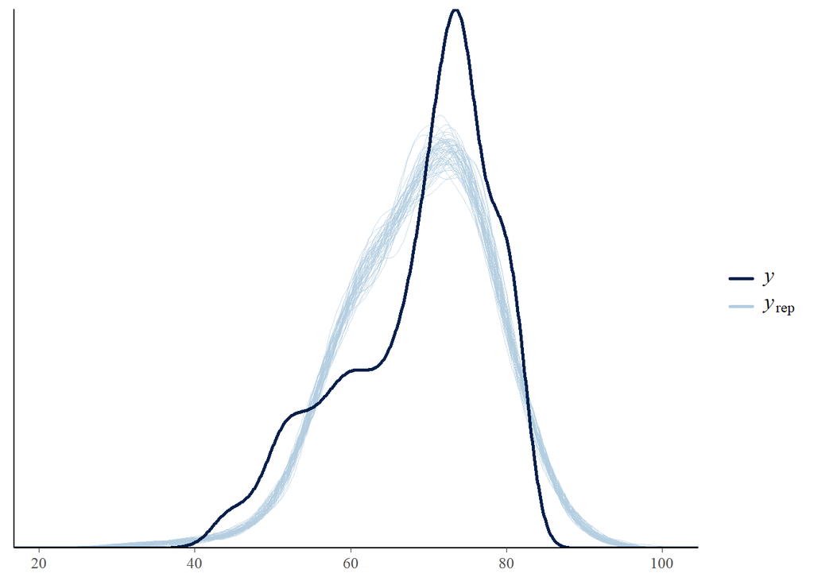

```r
# look at posterior predictive checks.
pp_check(glm_post1)
```

The dark blue line shows the observed data while the light blue lines are simulations from the posterior predictive distribution. Although the peaks of both the observed data distribution and the posterior distribution align along the x-axis, there’s a notable discrepancy in the density values along the y-axis.

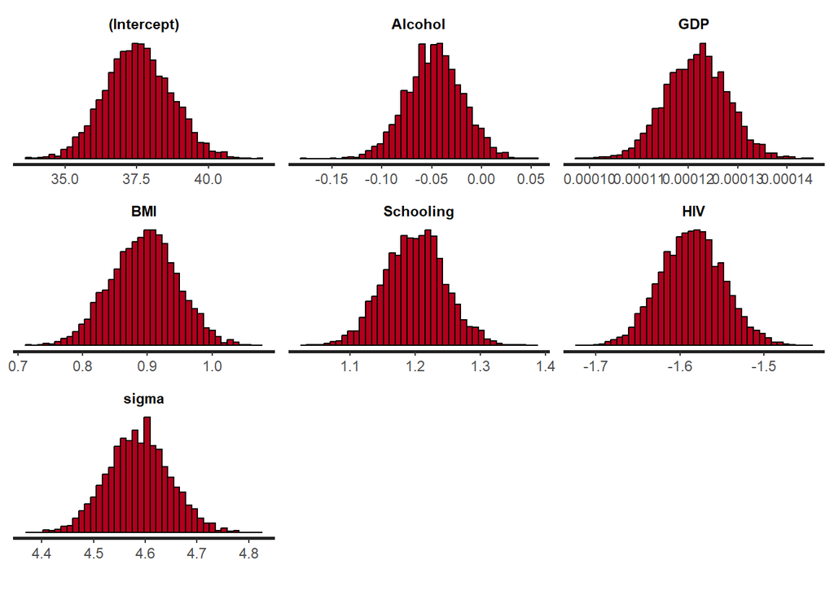

```r
# View histogram of each parameter
stan_hist(glm_post1, pars=c("(Intercept)","Alcohol", "GDP", "BMI", "Schooling", "HIV","sigma"), bins=40)
```

```r
# Extract posterior samples
post_samps <- as.data.frame(glm_post1, pars=c("(Intercept)","Alcohol", "GDP", "BMI",  "Schooling", "HIV","sigma"))

# calculate the median and mean of each parameter
round(apply(post_samps, 2, mean),5)
```

```
(Intercept)     Alcohol         GDP         BMI   Schooling         HIV
   37.54522    -0.04726     0.00012     0.89498     1.19895    -1.58586
      sigma
    4.58714
```

```r
round(apply(post_samps, 2, median),5)
```

```
(Intercept)     Alcohol         GDP         BMI   Schooling         HIV
   37.52769    -0.04706     0.00012     0.89646     1.19960    -1.58576
      sigma
    4.58648
```

The histograms exhibit the distribution of posterior samples obtained from the model. We also extracted posterior samples from the model and converted to a data frame in order to calculate the the mean and median values of each parameter.

```r
# Checking default priors
prior_summary(glm_post1)
```

```
Priors for model 'glm_post1'
------
Intercept (after predictors centered)
  Specified prior:
    ~ normal(location = 69, scale = 2.5)
  Adjusted prior:
    ~ normal(location = 69, scale = 24)

Coefficients
  Specified prior:
    ~ normal(location = [0,0,0,...], scale = [2.5,2.5,2.5,...])
  Adjusted prior:
    ~ normal(location = [0,0,0,...], scale = [ 0.0014,10.7179, 5.9052,...])

Auxiliary (sigma)
  Specified prior:
    ~ exponential(rate = 1)
  Adjusted prior:
    ~ exponential(rate = 0.11)
------
See help('prior_summary.stanreg') for more details
```

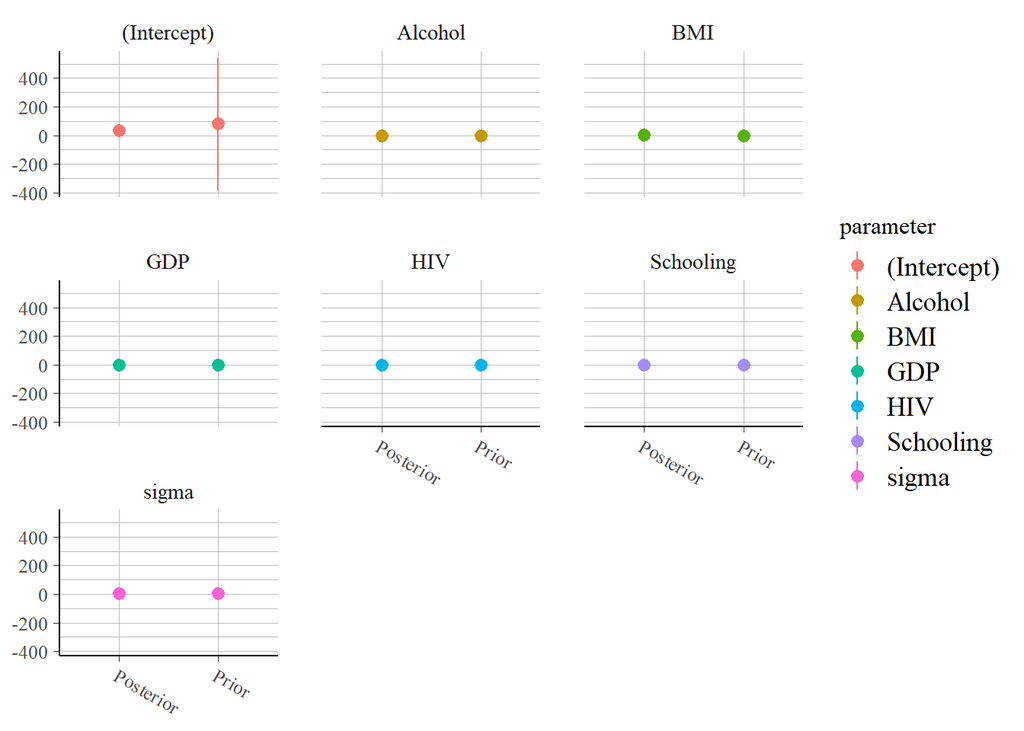

```r
# To see how the observed data has changed the parameter estimates
posterior_vs_prior(glm_post1, group_by_parameter = TRUE, pars=c("(Intercept)","Alcohol", "GDP", "BMI", "Schooling", "HIV","sigma"))
```

#### 3.3.3 Compare with Frenquentist method

```r
# Establish an Ordinary Linear Model
glm_fit <- glm(LifeExp~., data=BLR_data, family=gaussian)
summary(glm_fit)
```

```
Call:
glm(formula = LifeExp ~ ., family = gaussian, data = BLR_data)

Deviance Residuals:
     Min        1Q    Median        3Q       Max
-17.9434   -3.2096    0.1765    3.5416   16.8603

Coefficients:
              Estimate Std. Error t value Pr(>|t|)
(Intercept)  3.752e+01  1.137e+00  33.006   <2e-16 ***
GDP          1.216e-04  6.297e-06  19.319   <2e-16 ***
BMI          8.964e-01  5.143e-02  17.430   <2e-16 ***
Alcohol     -4.680e-02  2.818e-02  -1.661   0.0968 .
Schooling    1.198e+00  4.699e-02  25.488   <2e-16 ***
HIV         -1.586e+00  3.713e-02 -42.725   <2e-16 ***
---
Signif. codes:  0 '***' 0.001 '**' 0.01 '*' 0.05 '.' 0.1 ' ' 1

(Dispersion parameter for gaussian family taken to be 21.01963)

    Null deviance: 253277  on 2863  degrees of freedom
Residual deviance:  60074  on 2858  degrees of freedom
AIC: 16858

Number of Fisher Scoring iterations: 2
```

```r
round(glm_fit$coefficients, 5)
```

```
(Intercept)         GDP         BMI     Alcohol   Schooling         HIV
   37.51720     0.00012     0.89637    -0.04680     1.19761    -1.58617
```

The maximum likelihood estimates of the intercept and slopes are nearly identical to the mean or median values of posterior samples obtained from Bayesian Linear Regression. Overall, the model’s equation can be expressed as follows:

$$LifeExp = 37.5 + 0.9×BMI + 1.2×Schooling + -1.6×HIV$$

## References

Baldwin, Scott A, and Michael J Larson. 2017. “An Introduction to Using Bayesian Linear Regression with Clinical Data.” *Behaviour Research and Therapy* 98: 58–75.

Chen, Dongdong, Pin Lv, Lei Xue, Hongwen Xing, Lixin Lu, and Dongdong Kong. 2024. “Positional Error Compensation for Aviation Drilling Robot Based on Bayesian Linear Regression.” *Engineering Applications of Artificial Intelligence* 127: 107263.

Gill, Jeff. 2002. *Bayesian Methods: A Social and Behavioral Sciences Approach*. Chapman; Hall/CRC.

Hájek, Alan. 1996. “‘Mises Redux’—Redux: Fifteen Arguments Against Finite Frequentism.” *Erkenntnis* 45 (2-3): 209–27.

———. 2009. “Fifteen Arguments Against Hypothetical Frequentism.” *Erkenntnis* 70: 211–35.

Klauenberg, Katy, Gerd Wübbeler, Bodo Mickan, Peter Harris, and Clemens Elster. 2015. “A Tutorial on Bayesian Normal Linear Regression.” *Metrologia* 52 (6): 878.

Kruschke, John K. 2010. “Bayesian Data Analysis.” *Wiley Interdisciplinary Reviews: Cognitive Science* 1 (5): 658–76.

———. 2021. “Bayesian Analysis Reporting Guidelines.” *Nature Human Behaviour* 5 (10): 1282–91.

Marcotte, Denis, and Denis Allard. 2018. “Gibbs Sampling on Large Lattice with GMRF.” *Computers & Geosciences* 111: 190–99.

Minka, Thomas. 2000. “Bayesian Linear Regression.” Citeseer.

Pérez, Paulino, Gustavo de Los Campos, José Crossa, and Daniel Gianola. 2010. “Genomic-Enabled Prediction Based on Molecular Markers and Pedigree Using the Bayesian Linear Regression Package in r.” *The Plant Genome* 3 (2).

Permai, Syarifah Diana, and Heruna Tanty. 2018. “Linear Regression Model Using Bayesian Approach for Energy Performance of Residential Building.” *Procedia Computer Science* 135: 671–77.

Robert, Christian P, Vı́ctor Elvira, Nick Tawn, and Changye Wu. 2018. “Accelerating MCMC Algorithms.” *Wiley Interdisciplinary Reviews: Computational Statistics* 10 (5): e1435.

Rojas, Cristobal, and Michael Yampolsky. 2020. “How to Lose at Monte Carlo: A Simple Dynamical System Whose Typical Statistical Behavior Is Non-Computable.” In *Proceedings of the 52nd Annual ACM SIGACT Symposium on Theory of Computing*, 1066–72.

Rubio, Francisco J, and Marc G Genton. 2016. “Bayesian Linear Regression with Skew-Symmetric Error Distributions with Applications to Survival Analysis.” *Statistics in Medicine* 35 (14): 2441–54.

Seidou, Ousmane, JJ Asselin, and Taha BMJ Ouarda. 2007. “Bayesian Multivariate Linear Regression with Application to Change Point Models in Hydrometeorological Variables.” *Water Resources Research* 43 (8).

Shetty, Rahul, Brandon C Kelly, and Frank Bigiel. 2013. “Evidence for a Non-Universal Kennicutt–Schmidt Relationship Using Hierarchical Bayesian Linear Regression.” *Monthly Notices of the Royal Astronomical Society* 430 (1): 288–304.

Sugiarto, Sugiarto, Fadhlullah Apriandy, Yusria Darma, Sofyan M Saleh, Muhammad Rusdi, and Tomio Miwa. 2021. “Determining Passenger Car Equivalent (PCEs) for Pretimed Signalized Intersections with Severe Motorcycle Composition Using Bayesian Linear Regression.” *Plos One* 16 (9): e0256620.

Walker, Lawrence J, Paul Gustafson, and Jeremy A Frimer. 2007. “The Application of Bayesian Analysis to Issues in Developmental Research.” *International Journal of Behavioral Development* 31 (4): 366–73.

Zgheib, Elise, and Wassim Raphael. 2019. “Bayesian Linear Regression Analysis of the Effect of Silica Fume on Concrete Creep Predictions and Structures’ Safety.” *Procedia Structural Integrity* 22: 25–32.

Zhang, Xiaonan, Youliang Ding, Hanwei Zhao, and Letian Yi. 2022. “Long-Term Bridge Performance Assessment Using Clustering and Bayesian Linear Regression for Vehicle Load and Strain Mapping Model.” *Structural Control and Health Monitoring* 29 (12): e3118.

Zyphur, Michael J, and Frederick L Oswald. 2015. “Bayesian Estimation and Inference: A User’s Guide.” *Journal of Management* 41 (2): 390–420.